# LEfeeding_metaG_analysis

Load packages

```r
library(readr)
library(dplyr)
library(tidyverse)
library(stats)
library(purrr)
library(MASS)
library(rstatix)
library(ggtext)
library(car)
library(boot)
library(lme4)
```

Load metadata, q2q3 summary, and bin summary files.

```r
metadata <- as.data.frame(read_csv("~/Documents/UMich/papers/GrowthDefenseTradeOff/other output/metadata.csv"))
Q2Q3cov <- as.data.frame(read_table("~/Documents/UMich/papers/GrowthDefenseTradeOff/anvio files/MY_SUMMARY/bins_across_samples/mean_coverage_Q2Q3.txt")) # contains the q2q3 coverage info
bins_summary <- as.data.frame(read_table("~/Documents/UMich/papers/GrowthDefenseTradeOff/anvio files/MY_SUMMARY/bins_summary.txt")) # contains total_length, GC, completion, taxonomy etc. info
```

We will use sequence counts (read depth) for normalization so that we get a relative abundance proxy for across samples comparison.

```r
seqcounts <- read_csv("~/Documents/UMich/papers/GrowthDefenseTradeOff/QC/seqcounts.csv")
seqcounts <- head(seqcounts, 29) # remove rows with NA
mean(seqcounts$MSeqs)
```

```
## [1] 132.6897
```

```r
min(seqcounts$MSeqs)
```

```
## [1] 103.4
```

```r
max(seqcounts$MSeqs)
```

```
## [1] 177.7
```

Use minimum seq counts (here, 103.4) to get a ratio for each sample. Then multiply each sample’s read (q2q3) by its respective ratio.

```r
# calculate ratio
seqcounts$normalized_ratio <- seqcounts$MSeqs / 103.4

# convert Q2Q3 into compatible format
transposed_Q2Q3cov <- as.data.frame(t(Q2Q3cov)) # transpose Q2Q3coverage dataframe
colnames(transposed_Q2Q3cov) <- transposed_Q2Q3cov[1, ] # change column names to bin names
transposed_Q2Q3cov <- transposed_Q2Q3cov[-1, ] # remove the extra first row
transposed_Q2Q3cov$sample <- rownames(transposed_Q2Q3cov) # add a new sample column & revert rownames to numbers
rownames(transposed_Q2Q3cov) <- NULL

transposed_Q2Q3cov <- transposed_Q2Q3cov %>% # bring the sample column to be the first column in the df
  dplyr::select(sample, everything())

norm_Q2Q3cov <- inner_join(transposed_Q2Q3cov, seqcounts, by = "sample") # create a new df to store normalized values.

norm_Q2Q3cov <- norm_Q2Q3cov %>%
  dplyr::select(sample, normalized_ratio, contains("MAG")) # bring sample and normalized_ratio cols to the beginning and exclude total col

# calculate new values
num_cols <- names(norm_Q2Q3cov)[3:ncol(norm_Q2Q3cov)] # exclude  'sample' and 'normalized_ratio' cols
norm_Q2Q3cov[num_cols] <- lapply(norm_Q2Q3cov[num_cols], as.numeric)
norm_Q2Q3cov[num_cols] <- norm_Q2Q3cov[num_cols] * norm_Q2Q3cov$normalized_ratio
```

Combine normalized coverage with the metadata and save the new df.

```r
meta_covq2q3 <- inner_join(metadata, norm_Q2Q3cov, by = "sample")
write.csv(meta_covq2q3, "~/Documents/UMich/papers/GrowthDefenseTradeOff/R output/meta_covq2q3.csv")
```

Filter out low coverage samples (using detection data) to reduce noise. Detection values represent the proportion of a given contig that is covered at least 1X. So, the detection value of a bin is the average detection value of all the contigs that it contains.

```r
detection <- read_delim("~/Documents/UMich/papers/GrowthDefenseTradeOff/anvio files/MY_SUMMARY/bins_across_samples/detection.txt",
    delim = "\t", escape_double = FALSE,
    trim_ws = TRUE)
```

Look at distribution of detection values across samples.

Plot all the detection values together

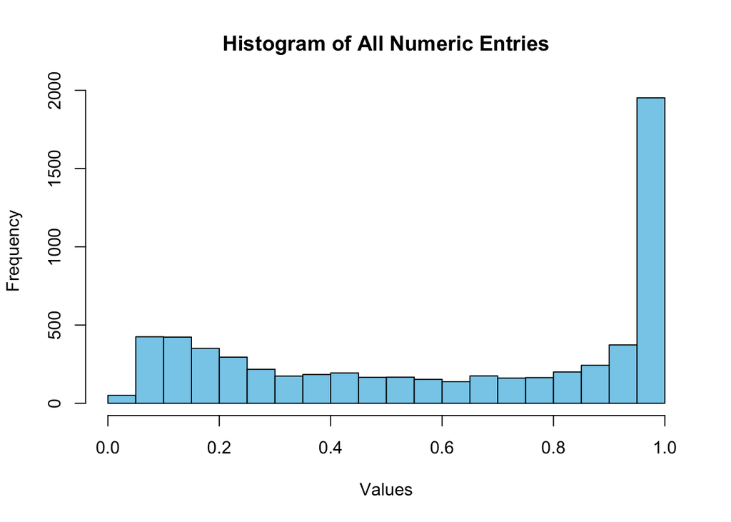

```r
# extract only numeric columns
numeric_data <- detection[sapply(detection, is.numeric)]

# combine all numeric columns into a single vector
all_values <- unlist(numeric_data)

# create a histogram for the combined values
hist(all_values, main = "Histogram of All Numeric Entries", xlab = "Values", col = "skyblue", border = "black")
```

Next, plot detection vs coverage - X axis as coverage and Y axis as detection. As coverage goes up, detection should go up but detection should saturate. Based on this relationship, we can figure out where to set the cutoff threshold for detection.

```r
# identify common columns that are numeric in both dataframes
common_columns <- intersect(names(Q2Q3cov), names(detection))
common_numeric_columns <- Filter(function(col) {
    is.numeric(Q2Q3cov[[col]]) && is.numeric(detection[[col]])
}, common_columns)

# open a new PDF file to save the plots
pdf("~/Documents/UMich/papers/GrowthDefenseTradeOff/R output/Figures/DetectionVsCov.pdf")

# loop through each common numeric column and create a scatter plot
for (column in common_numeric_columns) {
    plot_df <- data.frame(Q2Q3cov_Value = Q2Q3cov[[column]], Detection_Value = detection[[column]])
    p <- ggplot(plot_df, aes(x = Q2Q3cov_Value, y = Detection_Value)) +
        geom_point() +
        labs(title = paste("Scatter Plot for", column), x = paste("Q2Q3cov", column), y = paste("Detection", column)) +
        theme_minimal()
    print(p)
}

# close the PDF file
dev.off()
```

We will select 0.70 (70%) as the detection cutoff, as the relationship seems to scatter around here. 70% will also allow for strain variation while controlling for noise. We need to filter out low detection bins. Our goal is to evaluate the detection values for each bin within control samples for each date. If the mean detection value of a bin across control samples on a particular date is 70% or more, we will retain the coverage values for both control and quagga treatments for that bin on that date in the sub_covq2q3 dataframe. If the mean detection is less than 70%, we will set the coverage values to NA for that bin for both treatments on that date.

```r
# transform detection into percentage.
copied_detection <- detection %>%
  mutate(across(-1, ~ . * 100))

#%>% mutate(across(-1, ~ ifelse(. < 70, NA, .)))
# transpose detection data
transposed_detection <- t(copied_detection[-1]) # remove first col
transposed_detection <- as.data.frame(transposed_detection) # convert into df
colnames(transposed_detection) <- copied_detection[[1]]
transposed_detection$sample <- rownames(transposed_detection)
transposed_detection <- transposed_detection[, c("sample", setdiff(names(transposed_detection), "sample"))] # move sample col to 1st position

# extract relevant metadata
sub_covq2q3_relevant <- sub_covq2q3 %>% dplyr::select(sample, date, treatment)

# filter control samples
control_samples <- transposed_detection %>%
                    inner_join(sub_covq2q3_relevant, by = "sample") %>%
                    filter(treatment == "control")

# calculate mean detection for control samples
mean_detection <- control_samples %>%
                    group_by(date) %>%
                    dplyr::summarise(across(starts_with("ND"), mean, na.rm = TRUE))

# create a boolean matrix
boolean_detection <- transposed_detection

# adjust the col names
colnames(mean_detection)[-1] <- paste0(colnames(mean_detection)[-1], "_mean")

# apply the boolean condition; set value to TRUE (if the mean detection is not NA and ≥ 70 for the date) and FALSE (if otherwise).
for (i in 1:nrow(boolean_detection)) {
  sample <- boolean_detection$sample[i]
  sample_date <- sub_covq2q3_relevant$date[sub_covq2q3_relevant$sample == sample]

  if (length(sample_date) > 0) {
    for (bin in names(boolean_detection)[-1]) { # excluding the 'sample' column
      mean_det <- mean_detection %>%
                  filter(date == sample_date) %>%
                  pull(paste0(bin, "_mean"))

      boolean_detection[i, bin] <- !is.na(mean_det) && mean_det >= 70
    }
  }
}

# keep matching samples
matched_samples <- sub_covq2q3_relevant$sample
boolean_detection <- boolean_detection[boolean_detection$sample %in% matched_samples, ]

# filter coverage data
sub_covq2q3_coverage <- sub_covq2q3 %>% dplyr::select(-sample, -date, -treatment, -experiment, -normalized_ratio)
filtered_covinfo <- sub_covq2q3_coverage

# apply boolean
for (i in 1:nrow(filtered_covinfo)) {
  sample <- sub_covq2q3_relevant$sample[i]
  for (bin in names(filtered_covinfo)) {
    # Only apply filter if the sample exists in boolean_detection
    if (sample %in% boolean_detection$sample) {
      keep_value <- boolean_detection[boolean_detection$sample == sample, bin]
      if (!is.na(keep_value) && keep_value == 0) {
        filtered_covinfo[i, bin] <- NA
      }
    }
  }
}

# combine the updated coverage data and metadata
filtered_covinfo <- cbind(sub_covq2q3_relevant, filtered_covinfo)
```

The filtered_covinfo df contains the relevant q2q3 coverage values (normalized) for bins we want to include.

```r
write.csv(filtered_covinfo, "~/Documents/UMich/papers/GrowthDefenseTradeOff/R output/filtered_covinfo.csv")
```

Run GLM for each bin to test if statistical differences in the mean relative coverage between control and quagga treatments. We will use negative binomial family because of overdispersion in the data (tested earlier with Poisson and quasi-Poisson).

```r
# Function for GLM
perform_glm_nb <- function(dataframe, filter_day) {
  # Filter data for the specified day
  filtered_data <- dplyr::filter(dataframe, date == filter_day)

  # Prepare the result dataframe
  result_df <- data.frame(bin = character(), control_mean = numeric(),
                          quagga_mean = numeric(), p_value = numeric(),
                          sig = character(), stringsAsFactors = FALSE)

  # Get the list of "ND" column names
  nd_column_names <- grep("^ND", names(filtered_data), value = TRUE)

  for (nd_column in nd_column_names) {
    # Prepare data for GLM
    glm_data <- na.omit(filtered_data[, c('treatment', nd_column)])
    if (nrow(glm_data) > 1) {
      # Extracting and rounding means to four decimal places
      control_mean <- round(mean(glm_data[glm_data$treatment == 'control', nd_column], na.rm = TRUE), 4)
      quagga_mean <- round(mean(glm_data[glm_data$treatment == 'quagga', nd_column], na.rm = TRUE), 4)

      # Running Negative Binomial GLM
      glm_nb <- MASS::glm.nb(formula = as.formula(paste(nd_column, "~ treatment")), data = glm_data)

      # Extracting p-value
      p_value <- summary(glm_nb)$coefficients['treatmentquagga', 'Pr(>|z|)']

      # Adding to the result dataframe
      result_df <- rbind(result_df, data.frame(bin = nd_column,
                                               control_mean = control_mean,
                                               quagga_mean = quagga_mean,
                                               p_value = p_value,
                                               sig = ifelse(p_value < 0.05, "yes", "no"),
                                               direction = ifelse(control_mean > quagga_mean, "decrease", "increase"),
                                               date = filter_day))
    }
  }

  return(result_df)
}
```

Run GLM for the 3 experimental dates

```r
result_719 <- perform_glm_nb(filtered_covinfo, "7/19/19")
result_813 <- perform_glm_nb(filtered_covinfo, "8/13/19")
result_918 <- perform_glm_nb(filtered_covinfo, "9/18/19")
```

```r
result_719$sig_group <- with(result_719, ifelse(sig == "yes" & direction == "decrease", "sig_decrease", "other"))
result_813$sig_group <- with(result_813, ifelse(sig == "yes" & direction == "decrease", "sig_decrease", "other"))
result_918$sig_group <- with(result_918, ifelse(sig == "yes" & direction == "decrease", "sig_decrease", "other"))

# combine result dfs

combined_result <- rbind(result_719, result_813, result_918)

# combine with bins_summary df to add other details
colnames(bins_summary)[1] <- "bin"
bins_extendedinfo <- inner_join(bins_summary, combined_result)
```

Now the bins_extendedinfo df contains taxonomic information, control and quagga mean coverage values (scaled), statistical results comparing the means, and some other metadata information.

Generate a summary dfs categorizing MAGs by presence (present in all dates, present in 2 dates, and present once).

```r
# categorize MAGs by presence
mags_presence_count <- bins_extendedinfo %>%
  group_by(bin) %>%
  summarize(presence_count = n_distinct(date)) %>%
  mutate(presence_category = case_when(
    presence_count == 3 ~ 'Present in all 3 dates',
    presence_count == 2 ~ 'Present in 2 dates',
    presence_count == 1 ~ 'Present only once',
    TRUE ~ 'Unknown'
  ))

# determine the consistency of direction for each MAG
mags_direction_consistency <- bins_extendedinfo %>%
  group_by(bin) %>%
  dplyr::summarize(mags_direction_consistency = ifelse(n_distinct(direction) == 1, 'Consistent', 'Variable'))

# merge presence categories and direction consistency
mags_summary_table <- mags_presence_count %>%
  left_join(mags_direction_consistency, by = 'bin')

total_mags_presence_summary <- mags_summary_table %>%
  group_by(presence_category) %>%
  dplyr::summarize(
    n = n(),
    consistent = sum(mags_direction_consistency == 'Consistent'),
    variable = sum(mags_direction_consistency == 'Variable')
  )

# save dfs
write.csv(mags_summary_table, "~/Documents/UMich/papers/GrowthDefenseTradeOff/R output/mags_summary_table.csv")
write.csv(total_mags_presence_summary, "~/Documents/UMich/papers/GrowthDefenseTradeOff/R output/total_mags_presence_summary.csv")
```

Check if MAG persistence (frequency of presence - 1 time, 2 times, or 3 times) is correlated with resistance. Start by running anova to see if mean log2(q:c) ratios are different between mags in these 3 groups.

```r
# merge the dataframes
persistence_df <- merge(mags_summary_table, bins_extendedinfo, by = "bin")

# calculate the log2 ratio
persistence_df <- persistence_df %>%
  mutate(log2_ratio = log2(as.numeric(quagga_mean) / as.numeric(control_mean)))

# ANOVA
persistance_anova_result <- aov(log2_ratio ~ presence_category, data = persistence_df)
summary(persistance_anova_result)
```

```
##                    Df Sum Sq Mean Sq F value Pr(>F)
## presence_category   2    3.6   1.789   0.603  0.548
## Residuals         376 1115.9   2.968
```

```r
# set the order of categories explicitly
persistence_df$presence_category <- factor(persistence_df$presence_category,
                                            levels = c("Present in all 3 dates", "Present in 2 dates", "Present only once"))
```

Based on this the ANOVA test, there is no significant differences in the mean log2 ratios across the three persistence categories (F-statistic: 0.603, p value: 0.548). However, ANOVA assumes equal variance between groups. Therefore, run a Levene’s test to measure the equality of variance in the data between these groups. The null hypothesis for Levene’s test is that population variances are equal. If the p-value for Levene’s test is less than 0.05, it means that there is a difference between the variances in the population and the observed variance is unlikely to be explained based on random sampling.

```r
# Levene's Test
levene_test <- leveneTest(log2_ratio ~ presence_category, data = persistence_df)
levene_test
```

```
## Levene's Test for Homogeneity of Variance (center = median)
##        Df F value   Pr(>F)
## group   2  5.1405 0.006273 **
##       376
## ---
## Signif. codes:  0 '***' 0.001 '**' 0.01 '*' 0.05 '.' 0.1 ' ' 1
```

Statistic: 5.140; p-value: 0.006 The p-value of 0.006 indicates that the variances of log2ratios are significantly different across the persistence categories. This suggests that ANOVA results may be unreliable. So, transform the data for chi-sq test, and compare the proportion of MAGs that are resistant in each category. For MAGs that appear more than once, take the average log2 ratio to assign them a resistant of persistent category.

```r
# calculate the mean log2 ratio for each MAG
mean_log2_ratio <- persistence_df %>%
  group_by(bin) %>%
  summarise(mean_log2_ratio = mean(log2_ratio))

# classify each MAG based on mean log2 ratio
mean_log2_ratio <- mean_log2_ratio %>%
  mutate(resistant = ifelse(mean_log2_ratio > 0, 1, 0))

# determine the presence category for each unique MAG
presence_category <- persistence_df %>%
  group_by(bin) %>%
  summarise(presence_category = first(presence_category))

# combine the classification with the presence category
merged_chisq <- merge(mean_log2_ratio, presence_category, by = "bin")

# create a contingency table
contingency_table <- table(merged_chisq$presence_category, merged_chisq$resistant)
contingency_table
```

```
##
##                           0  1
##   Present in all 3 dates 58 17
##   Present in 2 dates     40  8
##   Present only once      54  4
```

```r
# perform Chi-Square Test
chi_sq_test <- chisq.test(contingency_table)
chi_sq_test
```

```
##
##  Pearson's Chi-squared test
##
## data:  contingency_table
## X-squared = 6.0655, df = 2, p-value = 0.04818
```

```r
# prepare data for plotting
chisq_proportion_data <- merged_chisq %>%
  group_by(presence_category) %>%
  summarise(total_count = n(),
            resistant_count = sum(resistant),
            proportion_resistant = resistant_count / total_count)

# set the order of categories explicitly
chisq_proportion_data$presence_category <- factor(chisq_proportion_data$presence_category,
                                            levels = c("Present in all 3 dates", "Present in 2 dates", "Present only once"))
```

The p-value of 0.04 here suggests that there is a significant difference between proportions of MAGs that are resistant between the persistance groups. Plot total number of MAGs and chi-sq proportions in a single plot (paper figure 5).

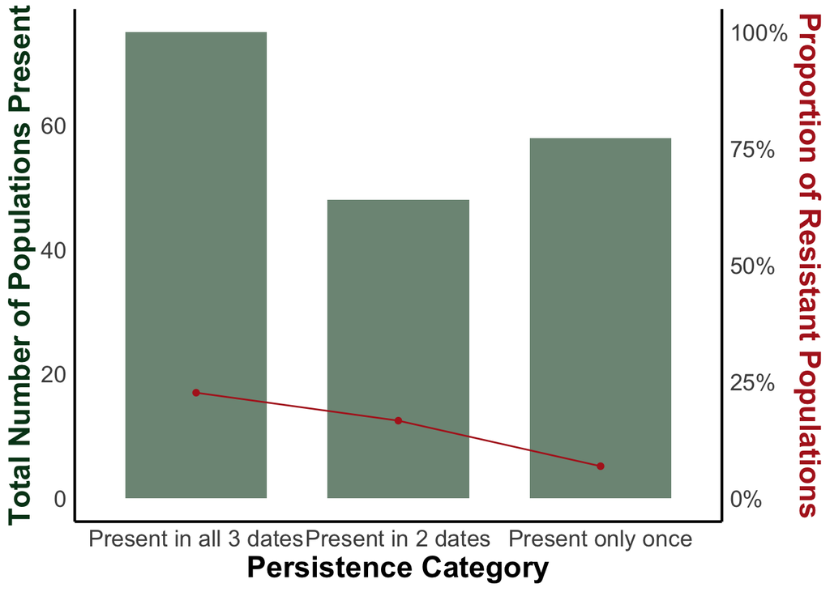

```r
Fig5 <- ggplot(chisq_proportion_data, aes(x = presence_category, y = total_count)) +
  geom_bar(stat = "identity", fill = "#02401B", alpha = 0.6, width = 0.7) +
  geom_line(aes(y = proportion_resistant * max(total_count), group = 1), color = "#B22222") +
  geom_point(aes(y = proportion_resistant * max(total_count)), color = "#B22222") +
  scale_y_continuous(sec.axis = sec_axis(~./max(chisq_proportion_data$total_count), name = "Proportion of Resistant Populations", labels = scales::percent)) +
  labs(x = "Persistence Category", y = "Total Number of Populations Present") +
  theme_minimal() +
  theme(
    plot.title = element_text(hjust = 0.5, face = "bold", size = 22),
    axis.title = element_text(size = 18, face = "bold"),
    axis.title.y.left = element_text(color = "#02401B"),
    axis.title.y.right = element_text(color = "#B22222"),
    axis.line = element_line(size = 0.8),
    axis.text.y = element_text(size = 14),
    axis.text.x = element_text(size = 14),
    legend.position = "right",
    legend.text = element_text(size = 14),
    legend.title = element_text(size = 16, face = "bold"),
    panel.grid.major = element_blank(),
    panel.grid.minor = element_blank()
    )
Fig5
```

```r
# plot
ggsave(filename = "~/Documents/UMich/papers/GrowthDefenseTradeOff/R output/Figures/Figure_5_persistence.jpg",
       plot = Fig5,
       width = 12, height = 9, dpi = 300, units = "in")
```

Next, check if rel. abundance (relative in this case) correlates with resistance. In other words, if abundant taxa are resistant. We will do bootstrapping to account for difference in sample size.

```r
# add resistance status col
cov_analysis <- bins_extendedinfo %>%
  mutate(resistance_status = ifelse(direction == "increase", "resistant", "susceptible"))

# extract control means
resistant_control_means <- cov_analysis %>% filter(resistance_status == "resistant") %>% pull(control_mean)
susceptible_control_means <- cov_analysis %>% filter(resistance_status == "susceptible") %>% pull(control_mean)

# make control means  numeric
resistant_control_means <- as.numeric(resistant_control_means)
susceptible_control_means <- as.numeric(susceptible_control_means)

# define bootstrap function for mean diff
mean_diff <- function(data, indices) {
  resistant_sample <- sample(data$resistant, length(data$resistant), replace = TRUE)
  susceptible_sample <- sample(data$susceptible, length(data$susceptible), replace = TRUE)
  return(mean(resistant_sample) - mean(susceptible_sample))
}

# combine control means into a single list
boot_data <- list(resistant = resistant_control_means, susceptible = susceptible_control_means)

# perform bootstrap resampling
set.seed(123) # seed for reproducibility
boot_results <- boot(data = boot_data, statistic = mean_diff, R = 10000)

# calculate 95% confidence interval
ci <- boot.ci(boot_results, type = "perc")

# print results
observed_mean_diff <- mean(resistant_control_means) - mean(susceptible_control_means)
print(observed_mean_diff)
```

```
## [1] -5.867208
```

```r
print(ci)
```

```
## BOOTSTRAP CONFIDENCE INTERVAL CALCULATIONS
## Based on 10000 bootstrap replicates
##
## CALL :
## boot.ci(boot.out = boot_results, type = "perc")
##
## Intervals :
## Level     Percentile
## 95%   (-12.141,   1.079 )
## Calculations and Intervals on Original Scale
```

Observed Mean Difference: -5.87 (resistant MAGs have, on average, lower control coverage than susceptible MAGs); 95% Confidence Interval: [-12.14, 1.08]. The confidence interval includes 0, indicating that the difference is not statistically significant at the 95% confidence level. This suggests that abundance does not correlate with resistance to feeding.

Run Levene’s test to compare if the variances are different

```r
# combine into a single data frame
control_means <- data.frame(
  value = c(resistant_control_means, susceptible_control_means),
  group = c(rep("resistant", length(resistant_control_means)), rep("susceptible", length(susceptible_control_means)))
)

# perform Levene's test for equal variances
levene_test <- leveneTest(value ~ group, data = control_means)
# print results
print(levene_test)
```

```
## Levene's Test for Homogeneity of Variance (center = median)
##        Df F value Pr(>F)
## group   1  1.9535  0.163
##       377
```

The p-value of 0.163 suggests that there is no statistically significant difference in the variances between the control means of the resistant and susceptible groups. At alpha level of 0.05, we fail to reject the null hypothesis for the Levene’s test. This further reinforces the idea that lack of relationship between abundance and resistance is real and not noise.

Test if GC percentage is different between are resistant and susceptible MAGs. Run Wilcoxon test

```r
# create list and get dates
GC_test_results_list <- list()
unique_dates <- unique(bins_extendedinfo$date)

# loop through each date
for (date in unique_dates) {
  subset_data <- bins_extendedinfo[bins_extendedinfo$date == date, ] # subset for current date
  test_result <- wilcox.test(GC_content ~ sig_group, data = subset_data) # perform Wilcoxon rank-sum test
  GC_test_results_list[[date]] <- test_result   # store the test result in the list
}
# print
GC_test_results_list
```

```
## $`7/19/19`
##
##  Wilcoxon rank sum test with continuity correction
##
## data:  GC_content by sig_group
## W = 1895, p-value = 0.1909
## alternative hypothesis: true location shift is not equal to 0
##
##
## $`8/13/19`
##
##  Wilcoxon rank sum test with continuity correction
##
## data:  GC_content by sig_group
## W = 2080, p-value = 0.6317
## alternative hypothesis: true location shift is not equal to 0
##
##
## $`9/18/19`
##
##  Wilcoxon rank sum test with continuity correction
##
## data:  GC_content by sig_group
## W = 1978, p-value = 0.08506
## alternative hypothesis: true location shift is not equal to 0
```

For all 3 dates, we see that the mean difference in GC percentage between resistant and susceptible MAGs is not statistically significant.

Next, check if the mean genome length varies between resistant and susceptible MAGs

```r
# repeat GC code but now for genome length
len_test_results_list <- list()
unique_dates <- unique(bins_extendedinfo$date)
for (date in unique_dates) {
  subset_data <- bins_extendedinfo[bins_extendedinfo$date == date, ]
  test_result <- wilcox.test(total_length ~ sig_group, data = subset_data)
  len_test_results_list[[date]] <- test_result
}
# print results
len_test_results_list
```

```
## $`7/19/19`
##
##  Wilcoxon rank sum test with continuity correction
##
## data:  total_length by sig_group
## W = 1969, p-value = 0.08671
## alternative hypothesis: true location shift is not equal to 0
##
##
## $`8/13/19`
##
##  Wilcoxon rank sum test with continuity correction
##
## data:  total_length by sig_group
## W = 2190, p-value = 0.3179
## alternative hypothesis: true location shift is not equal to 0
##
##
## $`9/18/19`
##
##  Wilcoxon rank sum test with continuity correction
##
## data:  total_length by sig_group
## W = 1345, p-value = 0.09315
## alternative hypothesis: true location shift is not equal to 0
```

We see that the total genome length also does NOT differ statistically between the two groups.

Instead of comapring the means between two categories of MAGs, let’s try plotting GC and genome length as continuous variable using linear model.

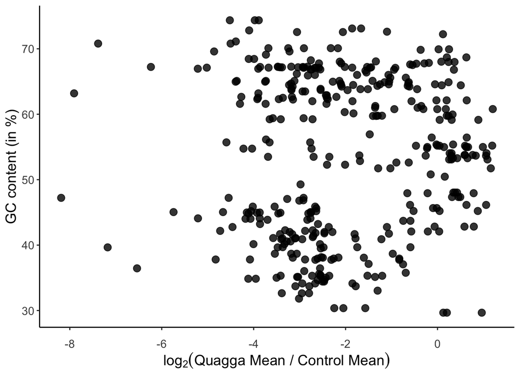

```r
# calculate Q:C mean ratio
cov_continuous <- bins_extendedinfo %>%
  dplyr::select(bin, GC_content, total_length, control_mean, quagga_mean, date) %>%
  dplyr::mutate(ratio = log2(quagga_mean/control_mean))

# GC plot
gc_plot <- ggplot(cov_continuous, aes(x = ratio, y = GC_content)) +
  geom_point(alpha=0.8, size = 3)+
  #stat_cor(method = "spearman", label.x.npc = 0.75, label.y.npc = 0.9, p.accuracy = 0.001, r.accuracy = 0.01)+
    labs(x= expression(log[2]("Quagga Mean / Control Mean")),
        y="GC content (in %)") +
  theme(plot.title = element_text(hjust = 0.5, size = 15, face="bold"),
          axis.title = element_text(size=14),
          axis.text = element_text(size=11),
          axis.text.x = element_text(vjust = -2),
          axis.title.x = element_text(vjust=-1),
        legend.position = c(0.93, 0.65),
        legend.title = element_text(size = 9),
          strip.background = element_blank(),
          panel.background = element_rect(fill = "white"),
          axis.line = element_line(colour = "black")
          )
gc_plot
```

```r
# model
gc_model <- lm(ratio ~ GC_content, data = cov_continuous)

# print
summary(gc_model)
```

```
##
## Call:
## lm(formula = ratio ~ GC_content, data = cov_continuous)
##
## Residuals:
##     Min      1Q  Median      3Q     Max
## -6.1288 -1.1986 -0.3086  1.4639  3.1869
##
## Coefficients:
##              Estimate Std. Error t value Pr(>|t|)
## (Intercept) -2.427870   0.398082  -6.099 2.65e-09 ***
## GC_content   0.007805   0.007264   1.074    0.283
## ---
## Signif. codes:  0 '***' 0.001 '**' 0.01 '*' 0.05 '.' 0.1 ' ' 1
##
## Residual standard error: 1.721 on 377 degrees of freedom
## Multiple R-squared:  0.003052,   Adjusted R-squared:  0.000408
## F-statistic: 1.154 on 1 and 377 DF,  p-value: 0.2833
```

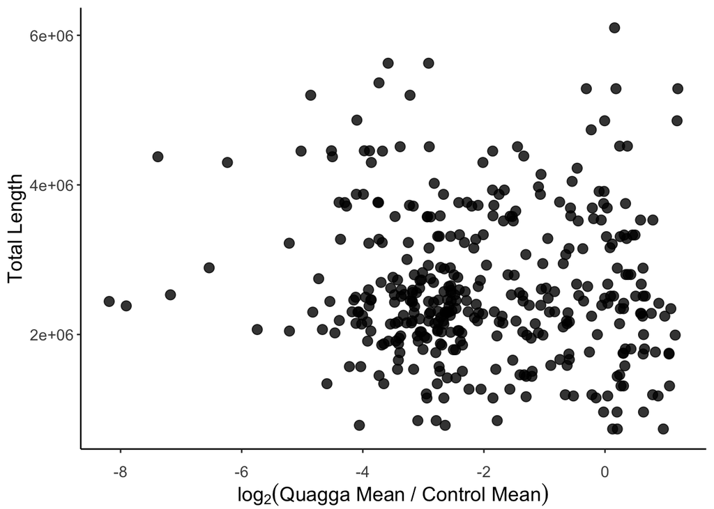

```r
# save
ggsave("~/Documents/UMich/papers/GrowthDefenseTradeOff/R output/Figures/gc_plot.png", plot = gc_plot, bg = "white")
length_plot <- ggplot(cov_continuous, aes(x = ratio, y = total_length)) +
  geom_point(alpha=0.8, size = 3)+
  #stat_cor(method = "spearman", label.x.npc = 0.75, label.y.npc = 0.9, p.accuracy = 0.001, r.accuracy = 0.01)+
    labs(x= expression(log[2]("Quagga Mean / Control Mean")),
        y="Total Length") +
  theme(plot.title = element_text(hjust = 0.5, size = 15, face="bold"),
          axis.title = element_text(size=14),
          axis.text = element_text(size=11),
          axis.text.x = element_text(vjust = -2),
          axis.title.x = element_text(vjust=-1),
        legend.position = c(0.93, 0.65),
        legend.title = element_text(size = 9),
          strip.background = element_blank(),
          panel.background = element_rect(fill = "white"),
          axis.line = element_line(colour = "black")
          )
length_plot
```

```r
length_model <- lm(ratio ~ total_length, data = cov_continuous)
summary(length_model)
```

```
##
## Call:
## lm(formula = ratio ~ total_length, data = cov_continuous)
##
## Residuals:
##     Min      1Q  Median      3Q     Max
## -6.1977 -1.1665 -0.3993  1.4486  3.5316
##
## Coefficients:
##                Estimate Std. Error t value Pr(>|t|)
## (Intercept)  -1.699e+00  2.505e-01  -6.785 4.52e-11 ***
## total_length -1.192e-07  8.972e-08  -1.329    0.185
## ---
## Signif. codes:  0 '***' 0.001 '**' 0.01 '*' 0.05 '.' 0.1 ' ' 1
##
## Residual standard error: 1.719 on 377 degrees of freedom
## Multiple R-squared:  0.004663,   Adjusted R-squared:  0.002023
## F-statistic: 1.766 on 1 and 377 DF,  p-value: 0.1847
```

```r
ggsave("~/Documents/UMich/papers/GrowthDefenseTradeOff/R output/Figures/length_plot.png", plot = length_plot, bg = "white")
```

Both GC content and total length do not predict feeding, as p-values for the regressions are above 0.05. Save dfs for MAGs that shifted significantly for anvio enrichment analysis (KEGG, pfam, and COG).

```r
# subset bins where sig is "yes"
sig_yes_data <- filter(bins_extendedinfo, sig == "yes")

# function to categorize direction
categorize_direction <- function(directions) {
  if (all(directions == "increase")) {
    return("resistant")
  } else if (all(directions == "decrease")) {
    return("susceptible")
  } else {
    return("mixed")
  }
}

# group by bin and categorize direction
sig_bins <- sig_yes_data %>%
  group_by(bin) %>%
  summarise(direction = categorize_direction(direction))

# rename columns
sig_bins <- rename(sig_bins, bin_name = bin, group = direction)
```

There are 151 unique MAGs that shifted significantly during atleast one experiment. This is out of 181 unique MAGs that we have total in the bins_extendedinfo df from 3 experimental dates (excluding July 31). Out of the 151 unique MAGs, 2 MAGs (ND57_MAG_00025, and ND57_MAG_00038) are in the mixed category (i.e. significantly variable response). Both MAGs belong to the Actinobacteriota phylum. 134 MAGs were consistently susceptible (i.e. decreased in the quagga treatment when present) and 15 MAGs were consistently resistant (increased significantly when present).

Save df with only resistant and susceptible MAGs for anvio analysis

```r
filtered_MAGs_sig <- sig_bins %>%
  dplyr::filter(group == "resistant" | group == "susceptible")
write.table(filtered_MAGs_sig, file = "~/Documents/UMich/papers/GrowthDefenseTradeOff/R output/sig_bins.tsv", sep = "\t", row.names = FALSE)
```

Make a list of bins for each date and save dfs

```r
july19_bins <- bins_extendedinfo %>%
  dplyr::filter(date == "7/19/19", control_mean > 0) %>%
  dplyr::select(bin, sig_group) %>%
  dplyr::rename(bin_name = bin, group = sig_group)
write.table(july19_bins, file = "~/Documents/UMich/papers/GrowthDefenseTradeOff/R output/july19_bins.tsv", sep = "\t", row.names = FALSE)


aug13_bins <- bins_extendedinfo %>%
  dplyr::filter(date == "8/13/19", control_mean > 0) %>%
  dplyr::select(bin, sig_group) %>%
  dplyr::rename(bin_name = bin, group = sig_group)
write.table(aug13_bins, file = "~/Documents/UMich/papers/GrowthDefenseTradeOff/R output/aug13_bins.tsv", sep = "\t", row.names = FALSE)


sep18_bins <- bins_extendedinfo %>%
  dplyr::filter(date == "9/18/19", control_mean > 0) %>%
  dplyr::select(bin, sig_group) %>%
  rename(bin_name = bin, group = sig_group)
write.table(sep18_bins, file = "~/Documents/UMich/papers/GrowthDefenseTradeOff/R output/sep18_bins.tsv", sep = "\t", row.names = FALSE)
```